# Ej09 sol

## Ejercicio 9

La fórmula de los trapecios simple es

$$ \int_{a}^{b}f(x)dx\approx \frac{b-a}{2}\;\left( f\left( a\right) +f\left( b\right) \right) .$$

Usar la fórmula de los trapecios para integrar una función en un intervalo, equivale a sustituir, dentro de la integral, la función a integrar por el polinomio de interpolación de grado uno, que pasa por los puntos de la función de los extremos del intervalo. Es decir, sustituimos la función por una recta e integramos. Estamos entonces calculando el área de un trapecio.

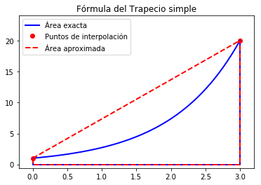

```
El valor aproximado es 31.628305
El valor exacto es     19.085537
```

```python
%matplotlib inline
%run TrapecioSimple.py
```

Una forma de disminuir el error de las fórmulas anteriores es aumentar el número de nodos utilizando las fórmulas compuestas. Estas se obtienen dividiendo el intervalo $\left[ a,b\right] $ en $n$ subintervalos y aplicando a cada uno de estos subintervalos una fórmula de cuadratura sencilla.

Si dividimos el intervalo $\left[ a,b\right] $ en $n$ subintervalos de igual longitud usando los nodos $x_{0},x_{1},...,x_{n}$,

la longitud de un subintervalo es

$$h=\frac{b-a}{n}$$

y los nodos son

$$x_i=a+i\,h \quad i=0,1,\ldots,n$$

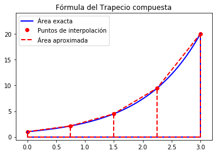

```
El valor aproximado es 19.971895
El valor exacto es     19.085537
```

```python
%run TrapecioCompuesta.py
```

Escribir la función **`trapecio_comp(f,a,b,n)`** que tiene como argumentos de entrada la función **`f`** a integrar, los extremos del intervalo de integración **`a`** y **`b`** y el número de subintervalos que vamos a usar en la fórmula compuesta **`n`** y devuelve el valor aproximado utilizando la Regla del Trapecio compuesta.

Calcular, con **`n = 4`** subintervalos, la integral

$$ \int_0^3 e^x \,dx$$

Obtener también el resultado con los datos

```python
f = lambda x: np.cos(x)
a = -np.pi/2; b = np.pi/2; n = 100
```

```python
f = lambda x : np.cosh(x)
a = -3; b = 3; n = 200;
```

```python
%matplotlib inline
import numpy as np
```

Usando la regla de los trapecios compuesta

$$\int_a^b f dx \approx \frac{h}{2}(f(a)+f(b))+h\sum_{i=1}^{n-1}f(x_i)$$

```python
def trapecio_comp(f,a,b,n):
    h = (b - a) / n
    x = np.arange(a+h, b, h)
    I = h*(f(a)+f(b))/2+h*np.sum(f(x));
    return I
```

```python
f = lambda x : np.exp(x)
a = 0.; b = 3; n = 4;
I = trapecio_comp(f,a,b,n)
print ('El valor aproximado para exp(x)  es %f' % (I))
```

```
El valor aproximado para exp(x)  es 19.971895
```

```python
f = lambda x : np.cos(x)
a = -np.pi/2; b = np.pi/2; n = 100;
I = trapecio_comp(f,a,b,n)
print ('El valor aproximado para cos(x)  es %f' % (I))
```

```
El valor aproximado para cos(x)  es 1.999836
```

```python
f = lambda x : np.cosh(x)
a = -3; b = 3; n = 200;
I = trapecio_comp(f,a,b,n)
print ('El valor aproximado para cosh(x) es %f' % (I))
```

```
El valor aproximado para cosh(x) es 20.339282
```